# p8105_hw3_ly2633

Leila Yan

2024-10-06

Load libraries

```r
library(tidyverse)
```

```r
library(ggplot2)
library(patchwork)
library(knitr)
```

### Problem 1

```r
library(p8105.datasets)
data("ny_noaa")
```

Do some data cleaning. Create separate variables for year, month, and day. Ensure observations for temperature, precipitation, and snowfall are given in reasonable units. For snowfall, what are the most commonly observed values? Why?

```r
ny_noaa_cleaned <- ny_noaa %>%
  janitor::clean_names()%>%
  drop_na() %>%
  mutate(
    year = year(date),
    month = month(date),
    day = day(date),
    tmax = as.numeric(tmax) / 10,
    tmin = as.numeric(tmin) / 10,
    prcp = as.numeric(prcp) / 10,
    snowfall = as.numeric(snow)
  )

common_snowfall <- ny_noaa_cleaned %>%
  count(snowfall) %>%
  arrange(desc(n))
common_snowfall
```

```
## # A tibble: 248 × 2
##    snowfall       n
##       <dbl>   <int>
##  1        0 1112758
##  2       25   15809
##  3       13   12460
##  4       51    9252
##  5        5    5669
##  6        8    5380
##  7       76    5296
##  8        3    5276
##  9       38    5050
## 10      102    3386
## # ℹ 238 more rows
```

The most commonly observed snowfall value is 0, with over 1.1 million instances. This is expected because many days in the dataset likely had no snowfall, especially in regions or seasons where snow is uncommon. Other common values, like 25, 13, 51, and 5, likely represent typical snowfall measurements in millimeters during snow events, but they occur much less frequently compared to zero snowfall days. The predominance of zero snowfall values is because, in many locations, snow only occurs seasonally or not at all, leading to many days with no snow recorded throughout the year.

### Problem 2

Load, tidy, merge, and otherwise organize the data sets. Your final dataset should include all originally observed variables; exclude participants less than 21 years of age, and those with missing demographic data; and encode data with reasonable variable classes (i.e. not numeric, and using factors with the ordering of tables and plots in mind).

```r
# load, tidy, merge, organize datasets
accel_df =
  read_csv("Data/nhanes_accel.csv") %>%
  janitor::clean_names()%>%
  drop_na()
Covar_df =
  read_csv("Data/nhanes_covar.csv", skip=4) %>%
  janitor::clean_names() %>%
  filter(age >= 21) %>%
  mutate(education=recode(education, "1" = "Less than high school", "2" = "High school equivalent", "3" = "More than high school"), sex=recode(sex, "1"="Male", "2" = "Female")) %>%
  drop_na()
merged_data = left_join(Covar_df, accel_df, by="seqn") %>%
  relocate("seqn","sex", "age", "bmi", "education") %>%
  mutate(across(seqn:education, as.character))
```

Produce a reader-friendly table for the number of men and women in each education category, and create a visualization of the age distributions for men and women in each education category. Comment on these items.

```r
# Prepare data to make the reader friendly table
education_sex_table = merged_data %>%
  mutate(education=recode(education, "1" = "Less than high school", "2" = "High school equivalent", "3" = "More than high school"), sex=recode(sex, "1"="Male", "2" = "Female")) %>%
  group_by(education, sex) %>%
  summarise(count = n(), .groups = 'drop')
```

```r
# Create a reader friendly table
kable(education_sex_table, col.names = c("Education", "Sex", "Count"),
      caption = "Education and Sex Distribution")
```

Education and Sex Distribution

| Education | Sex | Count |
| --- | --- | --- |
| High school equivalent | Female | 23 |
| High school equivalent | Male | 35 |
| Less than high school | Female | 28 |
| Less than high school | Male | 27 |
| More than high school | Female | 59 |
| More than high school | Male | 56 |

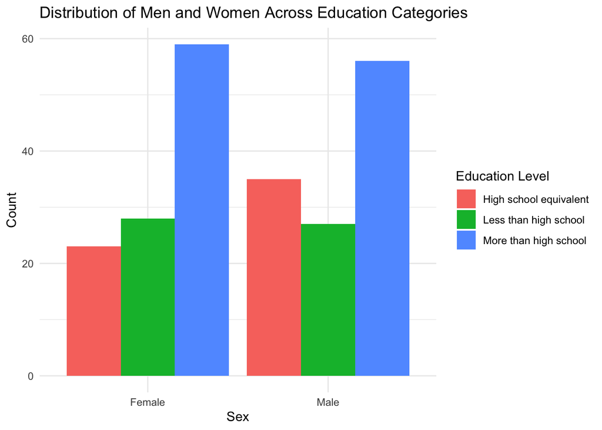

```r
# Create a barplot
barplot = ggplot(merged_data, aes(x = sex, fill = education)) +
  geom_bar(position = "dodge") +
  labs(title = "Distribution of Men and Women Across Education Categories",
       x = "Sex", y = "Count", fill = "Education Level") +
  theme_minimal()

barplot
```

Using your tidied dataset, aggregate across minutes to create a total activity variable for each participant. Plot these total activities (y-axis) against age (x-axis); your plot should compare men to women and have separate panels for each education level. Include a trend line or a smooth to illustrate differences. Comment on your plot.

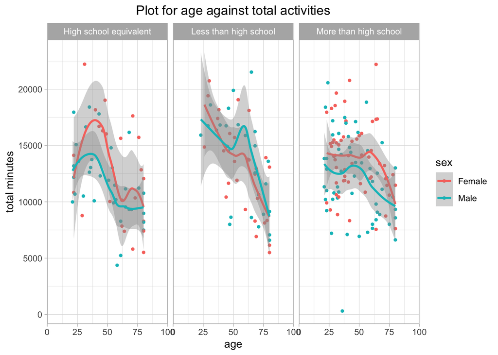

```r
# Aggregate the data
aggregate_df =
  merged_data %>%
  mutate(total_minutes= rowSums(select(., starts_with("min")))) %>%
  relocate("seqn","sex", "age", "bmi", "education", "total_minutes")

# Plot total activities against age
scatterplot_aggregate =
  aggregate_df %>%
  mutate(age=as.integer(age)) %>%
  ggplot(., mapping=aes(x=age, y=total_minutes, color=sex)) + geom_point(na.rm=TRUE, size=1) + theme_light() +
  ggtitle("Plot for age against total activities") + xlab("age") + ylab("total minutes") +
  scale_x_continuous(expand=c(0,0), limits=c(0, 100)) +theme(plot.title = element_text(hjust=0.5)) + geom_smooth() +
  facet_grid(. ~ education)

scatterplot_aggregate
```

Accelerometer data allows the inspection activity over the course of the day. Make a three-panel plot that shows the 24-hour activity time courses for each education level and use color to indicate sex. Describe in words any patterns or conclusions you can make based on this graph; including smooth trends may help identify differences.

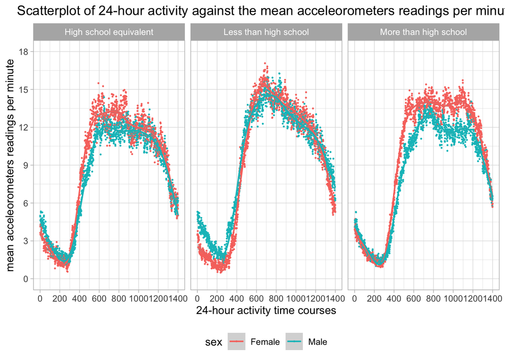

```r
# Get data ready for plotting
plot_longer = merged_data %>%
  pivot_longer(., cols= starts_with("min"), names_to = "minutes", values_to = "readings") %>%
  mutate(minutes = as.numeric(gsub("min", "", minutes)))

final_plot_df = merged_data %>%
  pivot_longer(., cols = starts_with("min"), names_to = "minutes", values_to = "readings") %>%
  mutate(minutes = as.numeric(gsub("min", "", minutes))) %>%
  group_by(minutes, sex, education) %>%
  summarise(mean=mean(readings, na.rm=TRUE))
# Plot the graph
scatterplot_24h_activity = ggplot(final_plot_df, mapping=aes(x=minutes, y=mean, color=sex)) + geom_point(size=0.25, rm.NA=TRUE) + theme_light() + facet_grid(.~ education) +
  geom_smooth(size=0.7) + scale_x_continuous(limits=c(0, 1400), breaks=seq(0, 1400, by=200)) +
  scale_y_continuous(limits=c(0,18), breaks=seq(0,18, by=3)) + xlab("24-hour activity time courses") + ylab("mean acceleorometers readings per minute") +
  ggtitle("Scatterplot of 24-hour activity against the mean acceleorometers readings per minute") + theme(legend.position = "bottom", plot.title=element_text(hjust=.5))
scatterplot_24h_activity
```

### Problem 3

Import, clean, and tidy these data, and describe the resulting dataset.

```r
Jan2020_df =
  read_csv("citibike/Jan 2020 Citi.csv") %>%
  janitor::clean_names() %>%
   mutate("year" = "2020", "month" = "Jan")
Jan2024_df =
  read_csv("citibike/Jan 2024 Citi.csv") %>%
  janitor::clean_names()%>%
   mutate("year" = "2024", "month" = "Jan")
July2020_df =
  read_csv("citibike/July 2020 Citi.csv") %>%
  janitor::clean_names() %>%
   mutate("year" = "2020", "month" = "July")
July2024_df =
  read_csv("citibike/July 2024 Citi.csv") %>%
  janitor::clean_names() %>%
   mutate("year" = "2024", "month" = "July")
```

Produce a reader-friendly table showing the total number of rides in each combination of year and month separating casual riders and Citi Bike members. Comment on these results.

```r
# Prepare the data for creating a reader-friendly table
all_data =
  bind_rows(Jan2020_df, Jan2024_df, July2020_df, July2024_df) %>%
  mutate(weekdays = factor(weekdays, levels = c("Monday", "Tuesday", "Wednesday", "Thursday", "Friday", "Saturday", "Sunday")))


ride_summary =
  all_data  %>%
  group_by(year, month, member_casual) %>%
  summarise(total_rides = n(), .groups = 'drop') %>%
  pivot_wider(names_from = member_casual, values_from = total_rides, values_fill = 0) %>%
  rename(Casual_Riders = casual, Citi_Bike_Members = member)

ride_summary
```

```
## # A tibble: 4 × 4
##   year  month Casual_Riders Citi_Bike_Members
##   <chr> <chr>         <int>             <int>
## 1 2020  Jan             984             11436
## 2 2020  July           5637             15411
## 3 2024  Jan            2108             16753
## 4 2024  July          10894             36262
```

```r
# Create a reader friendly table
kable(ride_summary,
      col.names = c("Year", "Month", "Casual Riders", "Citi Bike Members"),
      caption = "Ride Summary by Year and Month",
      format = "html",
      align = 'c')
```

Ride Summary by Year and Month

| Year | Month | Casual Riders | Citi Bike Members |
| --- | --- | --- | --- |
| 2020 | Jan | 984 | 11436 |
| 2020 | July | 5637 | 15411 |
| 2024 | Jan | 2108 | 16753 |
| 2024 | July | 10894 | 36262 |

Answers: Casual Riders: In January 2020, there were 984 rides by casual riders, which more than doubled by January 2024 (2,108 rides). A similar trend can be seen for July, with a substantial rise from 5,637 rides in July 2020 to 10,894 rides in July 2024.

Citi Bike Members: The growth in Citi Bike member rides is also notable. In January 2020, there were 11,436 rides, increasing to 16,753 rides in January 2024. The July data shows an even larger jump, from 15,411 rides in July 2020 to 36,262 rides in July 2024.

Make a table showing the 5 most popular starting stations for July 2024; include the number of rides originating from these stations.

```r
top_stations =
  July2024_df %>%
  group_by(start_station_name) %>%
  summarise(total_rides = n(), .groups = 'drop') %>%
  arrange(desc(total_rides)) %>%
  slice_max(total_rides, n = 5)
top_stations
```

```
## # A tibble: 5 × 2
##   start_station_name       total_rides
##   <chr>                          <int>
## 1 Pier 61 at Chelsea Piers         163
## 2 University Pl & E 14 St          155
## 3 W 21 St & 6 Ave                  152
## 4 West St & Chambers St            150
## 5 W 31 St & 7 Ave                  146
```

```r
# Create a reader friendly table
kable(top_stations,
      col.names = c("Station Name", "Total Rides"),
      caption = "Top 5 Stations with Most Rides in July 2024",
      format = "html",
      align = 'c')
```

Top 5 Stations with Most Rides in July 2024

| Station Name | Total Rides |
| --- | --- |
| Pier 61 at Chelsea Piers | 163 |
| University Pl & E 14 St | 155 |
| W 21 St & 6 Ave | 152 |
| West St & Chambers St | 150 |
| W 31 St & 7 Ave | 146 |

Answers: The most popular station is Pier 61 at Chelsea Piers with 163 rides, followed by University Pl & E 14 St and W 21 St & 6 Ave with 155 and 152 rides, respectively. This data suggests that these stations are key locations for bike-sharing services, likely reflecting high foot traffic and accessibility in these areas. The slight variations in ride numbers among these stations indicate that multiple points across the city are highly utilized, with no overwhelming dominance by any one station.

Make a plot to investigate the effects of day of the week, month, and year on median ride duration. This plot can include one or more panels, but should facilitate comparison across all variables of interest. Comment on your observations from this plot.

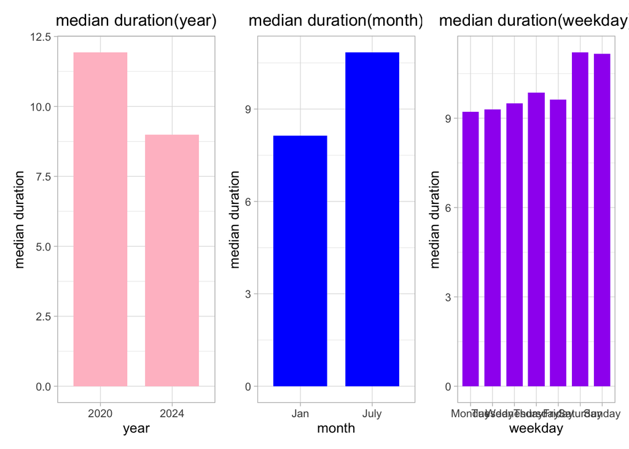

```r
# calculation the median ride duration
median_ride_duration_year = all_data %>%
  group_by(year) %>%
  summarize(median_duration = median(duration, na.rm=TRUE))

median_ride_duration_month = all_data %>%
  group_by(month) %>%
  summarize(median_duration = median(duration, na.rm=TRUE))

median_ride_duration_weekdays = all_data %>%
  group_by(weekdays) %>%
  summarize(median_duration = median(duration, na.rm=TRUE))

median_ride_duration_membership = all_data %>%
  group_by(member_casual) %>%
  summarize(median_duration = median(duration, na.rm=TRUE))

median_ride_duration_bike = all_data %>%
  group_by(rideable_type) %>%
  summarize(median_duration = median(duration, na.rm=TRUE))


# create the plots
plot_1 = ggplot(median_ride_duration_year, aes(x = year, y = median_duration)) +
             geom_bar(stat="identity", fill="pink", width=0.75) +
             xlab("year") + ylab("median duration") + ggtitle("median duration(year)") +
             theme_light() + theme(plot.title = element_text(hjust=0.5))

plot_2 = ggplot(median_ride_duration_month, aes(x = month, y = median_duration)) +
             geom_bar(stat="identity", fill="blue", width=0.75) +
             xlab("month") + ylab("median duration") + ggtitle("median duration(month)") + theme_light() + theme(plot.title = element_text(hjust=0.5))

plot_3 = ggplot(median_ride_duration_weekdays, aes(x = weekdays, y = median_duration)) +
             geom_bar(stat="identity", fill="purple", width=0.75) +
             xlab("weekday") + ylab("median duration") + ggtitle("median duration(weekday)") + theme_light() + theme(plot.title = element_text(hjust=0.5))

# final plot
plot_1 + plot_2 + plot_3
```

Comments: This plot illustrates the effects of year, month, and weekday on median ride duration. Over time, the median ride duration decreased from 2020 to 2024. Comparing months, July shows a longer median duration than January, likely reflecting seasonal factors such as warmer weather or more leisure activities in summer. Across the days of the week, ride durations remain relatively consistent, though weekends (Saturday and Sunday) have slightly longer durations, which may be due to more recreational riding compared to weekdays. These patterns suggest temporal variations in ride behavior.

There were relatively few electric Citi Bikes in 2020, but many more are available now. For data in 2024, make a figure that shows the impact of month, membership status, and bike type on the distribution of ride duration. Comment on your results.

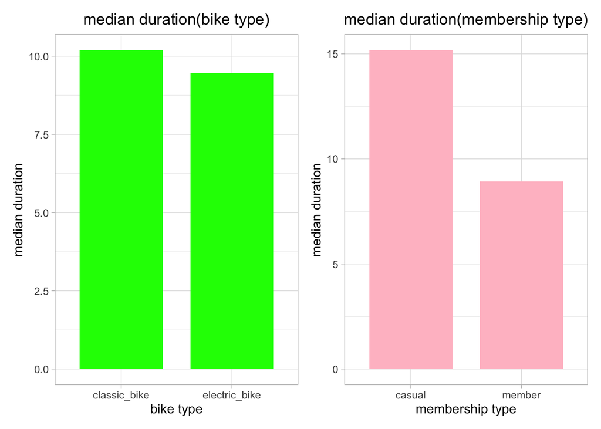

```r
# Membership status
membership_plot = ggplot(median_ride_duration_membership, aes(x = member_casual, y = median_duration)) +
             geom_bar(stat="identity", fill="pink", width=0.75) +
             xlab("membership type") + ylab("median duration") + ggtitle("median duration(membership type)") +
             theme_light() + theme(plot.title = element_text(hjust=0.5))


# Bike type
bike_plot = ggplot(median_ride_duration_bike, aes(x=rideable_type, y=median_duration)) +
             geom_bar(stat="identity", fill="green", width=0.75) +
             xlab("bike type") + ylab("median duration") + ggtitle("median duration(bike type)") +
             theme_light() + theme(plot.title = element_text(hjust=0.5))

bike_plot + membership_plot
```